# Dataset: ‘dataset_1’ LASSO summary

# Dataset: ‘dataset_8’ LASSO summary

## Full model prediction accuracy

| drug | 1 | 0 | 1/1 | 1/0 | 0/1 | 0/0 | precission | recall | f1 | accuracy |
| --- | --- | --- | --- | --- | --- | --- | --- | --- | --- | --- |
| CYCL | 4 | 39 | 0.093 | 0.0000 | 0 | 0.9070 | 1 | 1 | 1 | 1.0000 |
| PARA | 4 | 44 | 0.000 | 0.0833 | 0 | 0.9167 | NaN | 0 | NaN | 0.9167 |

## Reduced model prediction accuracy

| drug | 1 | 0 | 1/1 | 1/0 | 0/1 | 0/0 | precission | recall | f1 | accuracy |
| --- | --- | --- | --- | --- | --- | --- | --- | --- | --- | --- |
| CYCL | 4 | 39 | 0.0930 | 0 | 0 | 0.9070 | 1 | 1 | 1 | 1 |
| PARA | 4 | 44 | 0.0833 | 0 | 0 | 0.9167 | 1 | 1 | 1 | 1 |

## ‘CYCL’ Details

### Elastic Net for Best Lambda

Lambda that minimizes CV error

```
## [1] 0.02
```

Corresponding CV error

```
## [1] 0.2114
```

Number of nonzero coefficients (all non-zero)

```
## s49
##   6
```

Nonzero coefficients*:

| position | bp | coeficient |
| --- | --- | --- |
| 39 | 42227 | -5.0168 |
| 208 | 1619122 | -0.2132 |
| 244 | 1982083 | -0.2133 |
| 261 | 2163353 | -5.1925 |
| 262 | 2163357 | -0.0491 |
| 422 | 4247607 | -1.9734 |

### Charts

Nonzero coefficients (LASSO):

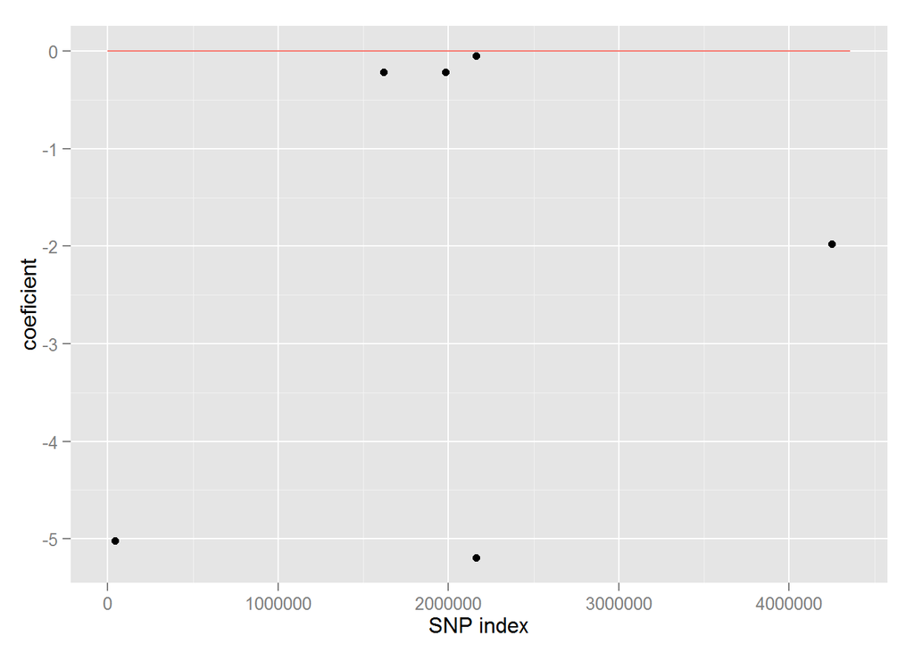

ROC curve for full model

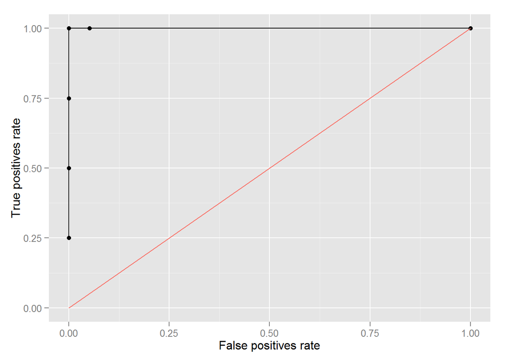

ROC curve for reduced model

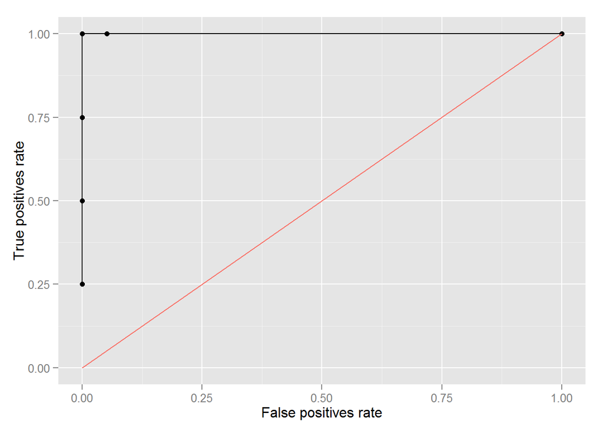

## ‘PARA’ Details

### Elastic Net for Best Lambda

Lambda that minimizes CV error

```
## [1] 0.12
```

Corresponding CV error

```
## [1] 0.5562
```

Number of nonzero coefficients (all non-zero)

```
## s44
##   3
```

Nonzero coefficients*:

| position | bp | coeficient |
| --- | --- | --- |
| 73 | 115154 | -2.249 |
| 137 | 699720 | -2.249 |
| 261 | 2163353 | -2.882 |

### Charts

Nonzero coefficients (LASSO):

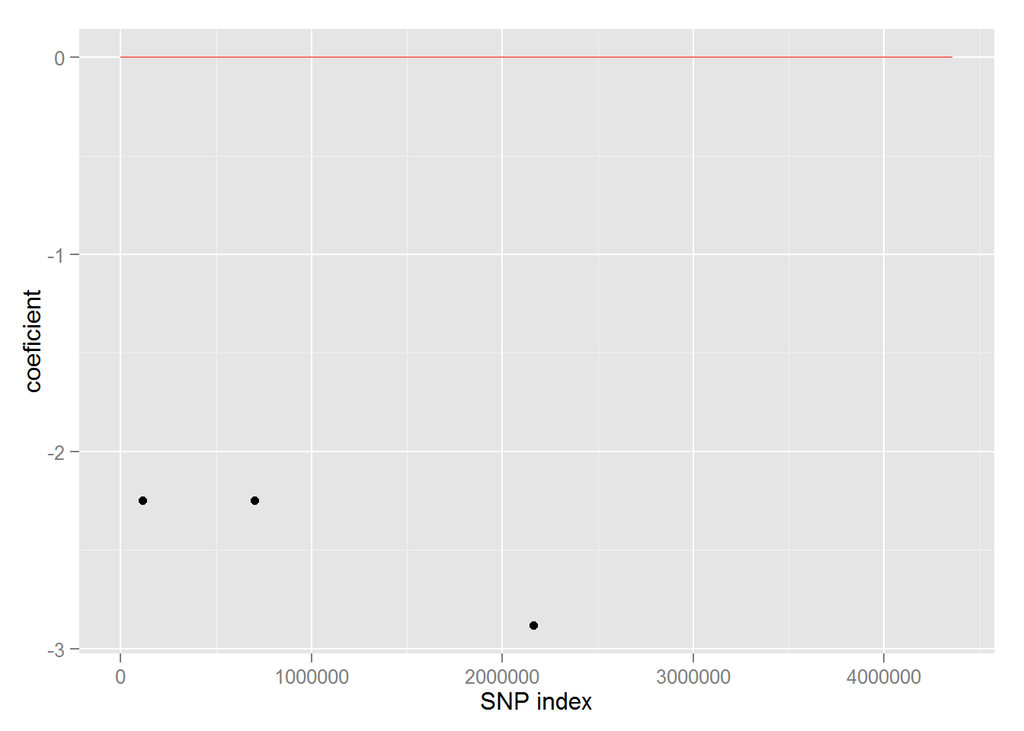

ROC curve for full model

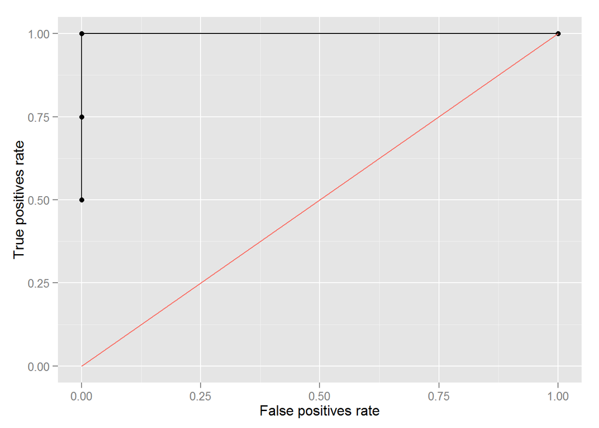

ROC curve for reduced model

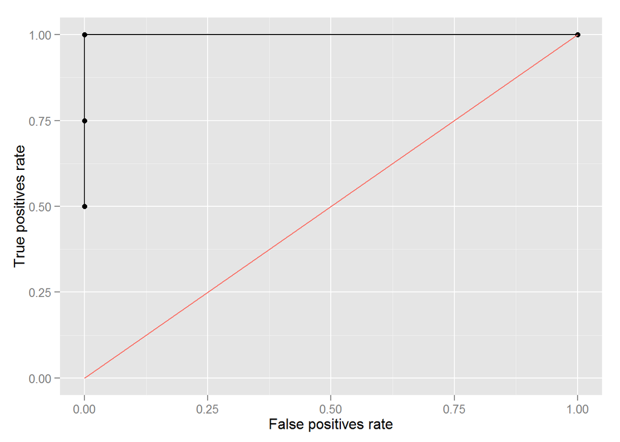

# Dataset: ‘dataset_9’ LASSO summary

## Full model prediction accuracy

| drug | 1 | 0 | 1/1 | 1/0 | 0/1 | 0/0 | precission | recall | f1 | accuracy |
| --- | --- | --- | --- | --- | --- | --- | --- | --- | --- | --- |
| CYCL | 46 | 70 | 0.3879 | 0.0086 | 0 | 0.6034 | 1 | 0.9783 | 0.9890 | 0.9914 |
| ETH | 33 | 89 | 0.2705 | 0.0000 | 0 | 0.7295 | 1 | 1.0000 | 1.0000 | 1.0000 |
| PARA | 22 | 100 | 0.1230 | 0.0574 | 0 | 0.8197 | 1 | 0.6818 | 0.8108 | 0.9426 |

## Reduced model prediction accuracy

| drug | 1 | 0 | 1/1 | 1/0 | 0/1 | 0/0 | precission | recall | f1 | accuracy |
| --- | --- | --- | --- | --- | --- | --- | --- | --- | --- | --- |
| CYCL | 46 | 70 | 0.3879 | 0.0086 | 0 | 0.6034 | 1 | 0.9783 | 0.9890 | 0.9914 |
| ETH | 33 | 89 | 0.2705 | 0.0000 | 0 | 0.7295 | 1 | 1.0000 | 1.0000 | 1.0000 |
| PARA | 22 | 100 | 0.1639 | 0.0164 | 0 | 0.8197 | 1 | 0.9091 | 0.9524 | 0.9836 |

## ‘CYCL’ Details

### Elastic Net for Best Lambda

Lambda that minimizes CV error

```
## [1] 0.04
```

Corresponding CV error

```
## [1] 1.04
```

Number of nonzero coefficients (all non-zero)

```
## s48
##  60
```

Nonzero coefficients*:

| position | bp | coeficient |
| --- | --- | --- |
| 8 | 6575 | 1.3521 |
| 9 | 6620 | -1.9930 |
| 13 | 7582 | -0.5684 |
| 21 | 17922 | -1.4512 |
| 31 | 35978 | -0.4184 |
| 43 | 70023 | -0.4387 |
| 58 | 103599 | -1.3432 |
| 79 | 122106 | -0.0133 |
| 89 | 247551 | -0.8959 |
| 90 | 285751 | 0.1700 |
| 103 | 333682 | -0.0140 |
| 110 | 336081 | 0.0153 |
| 111 | 336369 | 0.2670 |
| 115 | 336617 | 0.0470 |
| 121 | 336846 | 0.0621 |
| 135 | 365328 | 0.0357 |
| 167 | 528976 | 1.7458 |
| 171 | 627688 | 0.0184 |
| 173 | 656166 | 0.4169 |
| 175 | 715659 | 0.4835 |
| 176 | 761142 | -0.2576 |
| 178 | 764825 | -1.9679 |
| 179 | 770090 | -0.1451 |
| 181 | 781825 | 0.1243 |
| 182 | 812918 | -1.0812 |
| 193 | 889037 | -0.7115 |
| 208 | 973064 | 0.7731 |
| 209 | 1001128 | -0.7874 |
| 220 | 1096209 | 0.2051 |
| 226 | 1096571 | 1.0911 |
| 305 | 1618638 | -0.8846 |
| 307 | 1619121 | -1.1280 |
| 308 | 1619122 | -1.1822 |
| 318 | 1634615 | 0.1305 |
| 328 | 1636986 | -0.8390 |
| 334 | 1637662 | 0.2175 |
| 359 | 1853008 | 0.4485 |
| 379 | 1998264 | 0.6944 |
| 396 | 2155175 | 0.3749 |
| 402 | 2163353 | -0.9762 |
| 435 | 2289048 | 0.8450 |
| 436 | 2289260 | -1.4167 |
| 477 | 2828872 | -0.5451 |
| 507 | 3122932 | -0.5737 |
| 523 | 3382091 | -0.0400 |
| 530 | 3481957 | -0.0198 |
| 546 | 3712081 | -0.2146 |
| 556 | 3732418 | -0.0996 |
| 559 | 3732827 | -0.1018 |
| 560 | 3732829 | -0.3111 |
| 563 | 3732845 | 1.2352 |
| 576 | 3747067 | -0.5253 |
| 580 | 3754038 | -0.1384 |
| 585 | 3802338 | 0.2013 |
| 633 | 3934118 | 0.0414 |
| 648 | 3936517 | -0.2381 |
| 661 | 3946974 | 0.2115 |
| 663 | 3947022 | 0.0216 |
| 681 | 4156277 | 0.1768 |
| 690 | 4247607 | -0.5592 |

### Charts

Nonzero coefficients (LASSO):

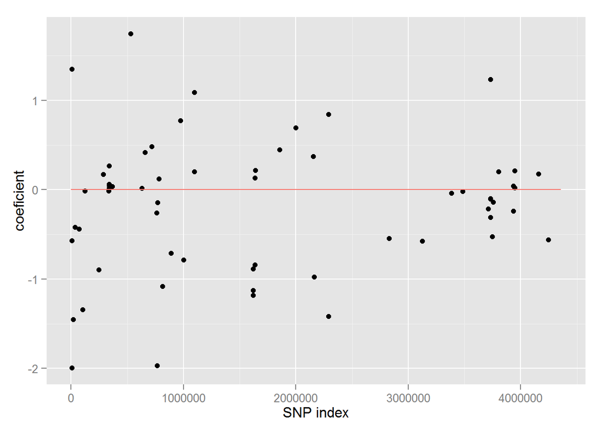

ROC curve for full model

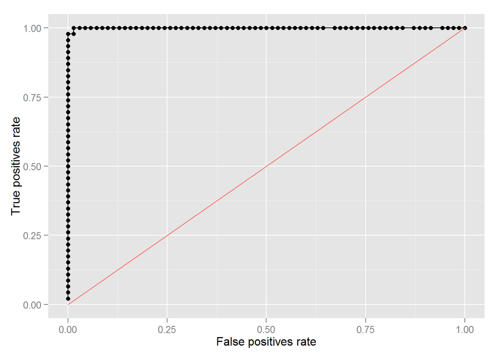

ROC curve for reduced model

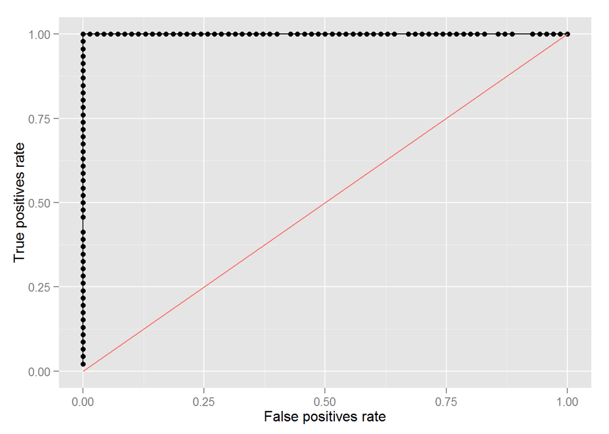

## ‘ETH’ Details

### Elastic Net for Best Lambda

Lambda that minimizes CV error

```
## [1] 0.02
```

Corresponding CV error

```
## [1] 0.6736
```

Number of nonzero coefficients (all non-zero)

```
## s49
##  66
```

Nonzero coefficients*:

| position | bp | coeficient |
| --- | --- | --- |
| 8 | 6575 | 0.0413 |
| 12 | 7581 | -0.2582 |
| 13 | 7582 | 0.0047 |
| 55 | 96675 | -0.4017 |
| 66 | 104912 | 1.8641 |
| 79 | 122106 | -0.9733 |
| 83 | 154281 | -2.4893 |
| 93 | 301489 | -1.2353 |
| 102 | 333641 | 0.8016 |
| 109 | 336074 | 0.0440 |
| 130 | 338768 | 0.1062 |
| 145 | 423970 | -3.9683 |
| 151 | 426977 | 0.2192 |
| 154 | 426989 | -0.4815 |
| 155 | 426992 | 0.2524 |
| 167 | 528976 | -1.1371 |
| 173 | 656166 | -2.4960 |
| 178 | 764825 | -2.5762 |
| 189 | 839985 | 0.2361 |
| 193 | 889037 | -0.3122 |
| 196 | 890721 | 0.1818 |
| 204 | 927066 | 0.3652 |
| 211 | 1040013 | -1.5388 |
| 219 | 1096006 | -0.4550 |
| 226 | 1096571 | 0.2402 |
| 236 | 1191467 | 0.3001 |
| 253 | 1276437 | 0.2847 |
| 259 | 1276858 | 0.4958 |
| 261 | 1276890 | 0.3492 |
| 281 | 1457150 | -0.5330 |
| 283 | 1468214 | -0.7317 |
| 285 | 1473252 | -0.8885 |
| 320 | 1636179 | 1.8834 |
| 340 | 1673431 | -1.7687 |
| 341 | 1673438 | -0.1266 |
| 343 | 1698917 | 0.2264 |
| 349 | 1788634 | 0.0083 |
| 356 | 1789678 | -0.3009 |
| 359 | 1853008 | 0.3986 |
| 367 | 1983320 | 0.2360 |
| 369 | 1989049 | 0.2286 |
| 376 | 1996403 | 0.1252 |
| 386 | 2116910 | -0.1036 |
| 389 | 2123176 | -0.0975 |
| 405 | 2163797 | 0.2642 |
| 412 | 2169070 | -0.3928 |
| 413 | 2169072 | -0.3273 |
| 417 | 2196889 | -0.0091 |
| 434 | 2288735 | -0.2951 |
| 436 | 2289260 | 0.0901 |
| 444 | 2301790 | -0.3613 |
| 492 | 2944749 | -1.8972 |
| 497 | 2955148 | -0.8951 |
| 507 | 3122932 | 4.4535 |
| 535 | 3491581 | 0.5688 |
| 542 | 3710566 | 0.6622 |
| 579 | 3753287 | 0.0682 |
| 604 | 3884024 | -0.2482 |
| 607 | 3884523 | 0.2660 |
| 629 | 3927774 | -0.8349 |
| 648 | 3936517 | -0.4397 |
| 649 | 3941765 | -0.8347 |
| 650 | 3942660 | 0.1808 |
| 657 | 3943903 | -0.0793 |
| 658 | 3943928 | -0.6829 |
| 661 | 3946974 | 1.7151 |

### Charts

Nonzero coefficients (LASSO):

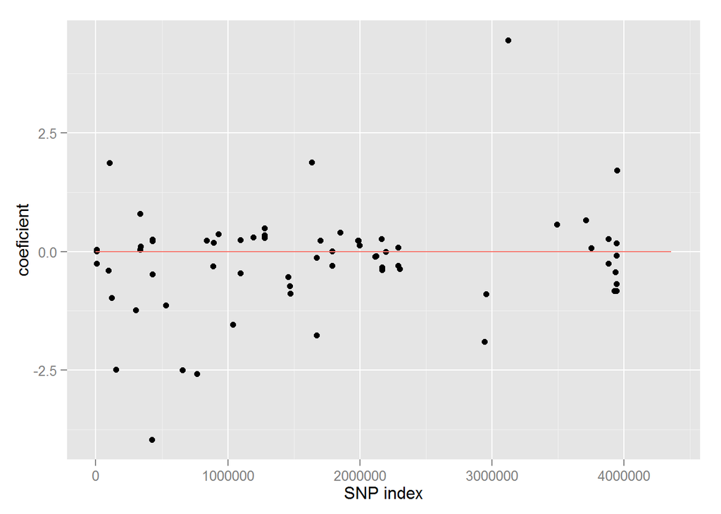

ROC curve for full model

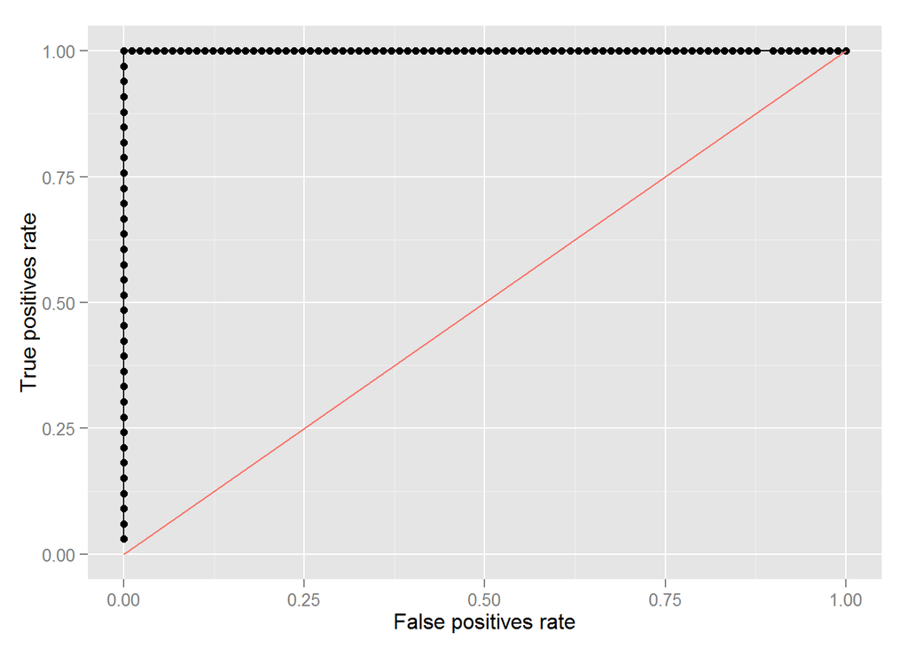

ROC curve for reduced model

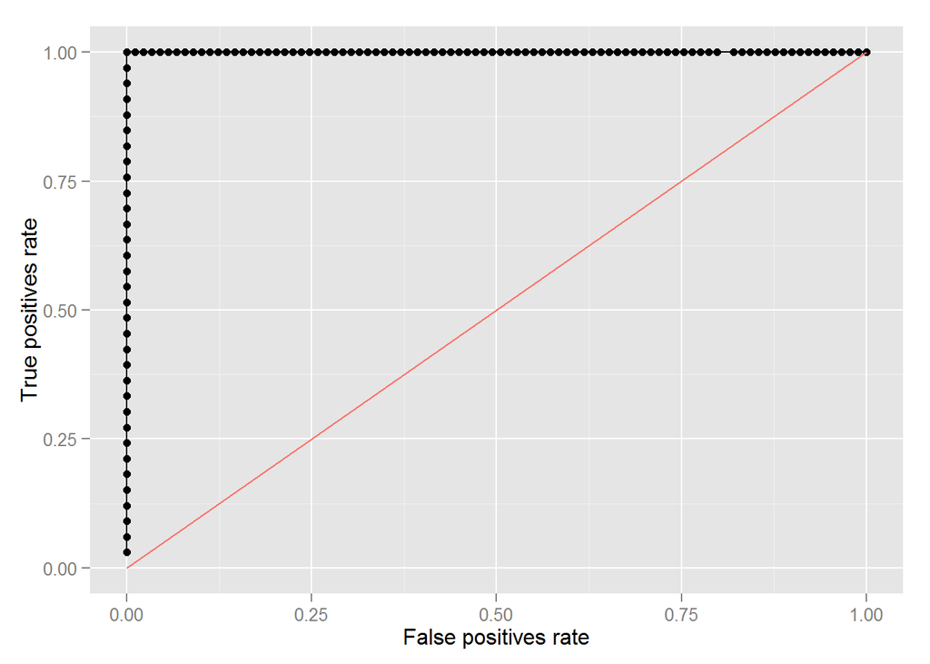

## ‘PARA’ Details

### Elastic Net for Best Lambda

Lambda that minimizes CV error

```
## [1] 0.06
```

Corresponding CV error

```
## [1] 0.6762
```

Number of nonzero coefficients (all non-zero)

```
## s47
##  22
```

Nonzero coefficients*:

| position | bp | coeficient |
| --- | --- | --- |
| 1 | 698 | -0.6945 |
| 21 | 17922 | -2.8348 |
| 78 | 116944 | -2.8348 |
| 84 | 173931 | -1.9844 |
| 103 | 333682 | -0.3268 |
| 166 | 487328 | -0.6150 |
| 172 | 656146 | -3.0235 |
| 220 | 1096209 | -0.1307 |
| 264 | 1303100 | -0.2686 |
| 283 | 1468214 | -0.0519 |
| 304 | 1618635 | -1.5256 |
| 305 | 1618638 | -0.0551 |
| 313 | 1633632 | -0.4176 |
| 398 | 2157774 | -0.6609 |
| 402 | 2163353 | -0.0901 |
| 452 | 2365424 | 0.1724 |
| 453 | 2365425 | 0.0931 |
| 531 | 3481990 | 0.1317 |
| 544 | 3711892 | 0.3116 |
| 545 | 3711893 | 0.1000 |
| 617 | 3895261 | -1.0359 |
| 674 | 4053229 | -0.2664 |

### Charts

Nonzero coefficients (LASSO):

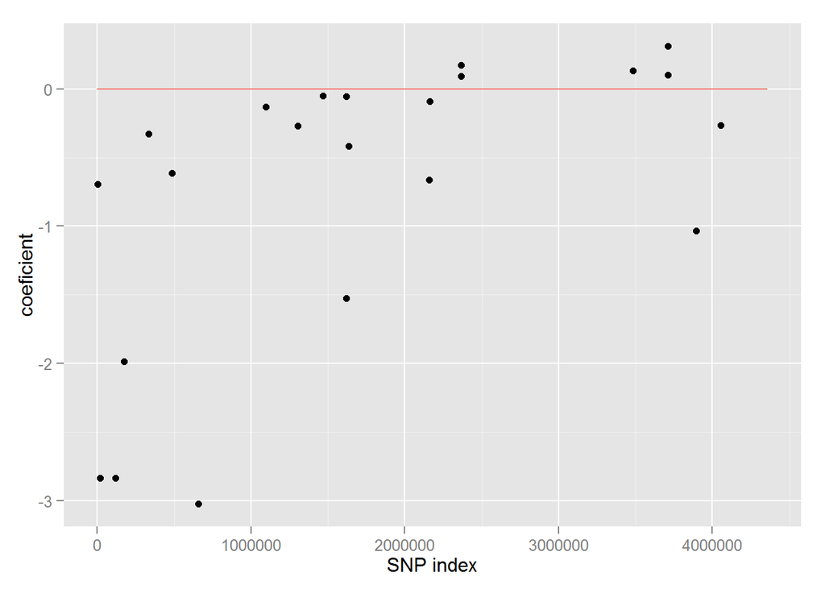

ROC curve for full model

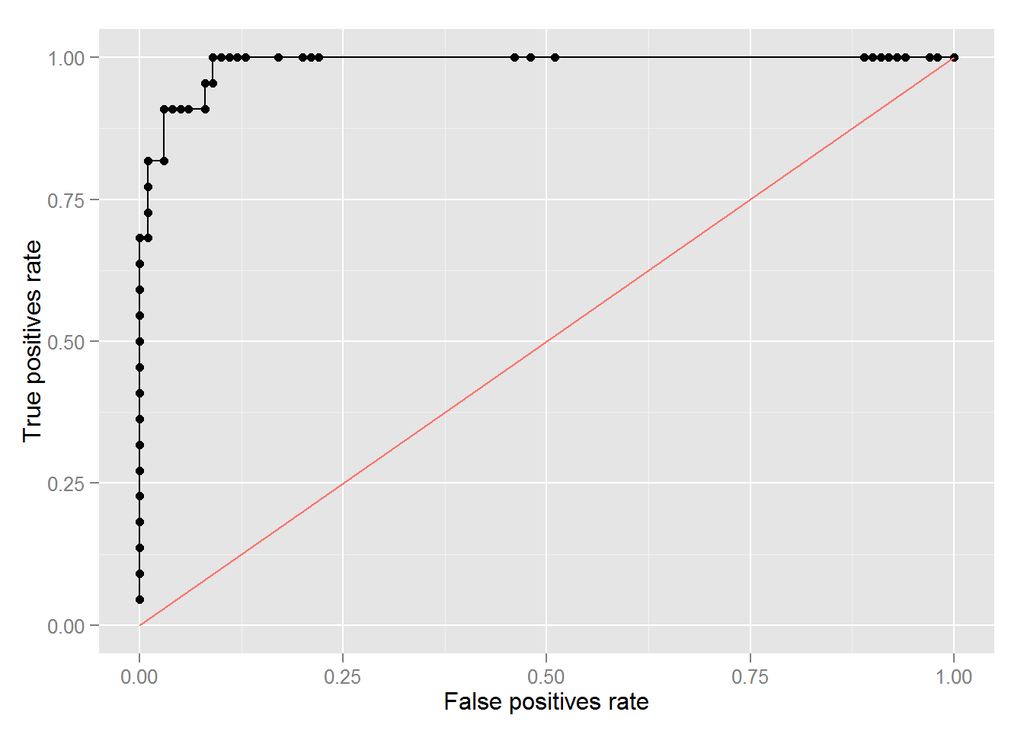

ROC curve for reduced model

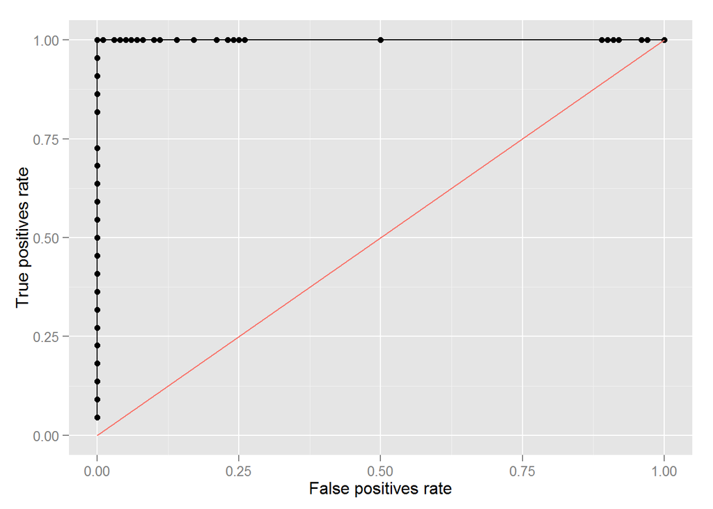